# The Gender Gap Is a Subtraction

Fifty-two years of party identification, the one number everybody quotes, and the two numbers underneath it

Democracy’s Data

Last updated September 13, 2026 at 10:53a EDT

Women lean Democratic and men do not. You have heard that claim, usually with a number attached: **the gender gap**, one of the most-quoted figures in American politics. This brief asks the two questions the quote skips. How big is the gap, really — and is it growing because women moved, because men moved, or both?

The gap is a subtraction. Somebody computes a number for women, computes a number for men, and prints the difference between them. What almost never gets printed is the pair, and the pair is where the story is.

## The test

The measure is party identification from the General Social Survey, the **GSS**, a survey of American adults’ attitudes and habits that NORC, a research organisation at the University of Chicago, has run since 1972 and posts for anyone to download. Its cumulative file, release 3a, holds 75,699 respondents interviewed between 1972 and 2024, from [NORC’s data page](https://gss.norc.org/us/en/gss/get-the-data.html). The same question, in the same words, has been asked in every round since 1972. That is what a claim about change requires, and it exists only because NORC kept asking those words for fifty-two years.

Party identification is the kind of measure no election ever grades. A poll about a vote is eventually scored against a result; a question about which party you feel you belong to never is, because there is no true national figure to score it against. So the design and the weighting carry the whole burden of the claim, where weighting means counting some answers more than others, to make the sample look like the country. The ANES chapter walks through that discipline for the book’s Public Opinion cluster, and this brief applies it to a second file built the same way.

Why the GSS and not the ANES itself? Partly access: the ANES file must be downloaded by hand from a registered account, and the survey access chapter measures those doors directly, while the GSS posts its file for anybody to take. That is a fact about access rather than quality, and it decides which survey a student can rebuild from scratch. The test itself is simple: compute the gap the way it is usually reported, then undo the subtraction and see which of its two halves moved.

## The data

The GSS publishes its cumulative file as one 47 MB zip holding a 570 MB file in Stata’s format, `gss7224_r3a.dta`, with 6,943 columns. Nine of them are used here, and the small tables this brief rests on were cut from those nine; the giant source is not kept in this brief’s folder, the tables are.

Three variables do the work. `partyid` runs 0 (strong Democrat) to 6 (strong Republican), with 7 for “other party.” **Net Democratic identification** is the weighted share at codes 0–2 minus the share at codes 4–6: if in some year 45% of women call themselves Democrats and 30% Republicans, women’s net Democratic identification is +15, and if the two shares are equal it is zero. The leaners at codes 2 and 4 — people who first called themselves independents and then, asked which party they felt closer to, named one — count with the party they lean toward, a decision the party identification brief takes apart. Code 7 belongs to neither side and is dropped. `sex` is the two-box item asked since 1972, and `wtssps` is the one weight that spans every year in the file, so the same adjustment is applied throughout and the series has no break where the method changed.

The derived tables are three. `partyid_by_sex.csv` holds `men`, `women`, the `gap` between them, and the sample sizes `n_men` and `n_women` for every survey year. `by_decade.csv` collapses the same series into decade averages. `partyid_by_sex_marital.csv` splits each sex again by marital status.

> **Before you read on, commit to two numbers.** In 1972 men and women were within a point and a half of each other, both about 29.7 points net Democratic. Today the gap between them is about 14.0 points. **Which side moved, and by how much?** Write down a number for each.

## What it says about democracy

Here is the gap, drawn the way it is usually drawn.

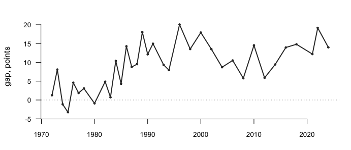

**Figure 1. Women’s net Democratic identification minus men’s, every GSS year from 1972 to 2024.** One line on a time axis, because one number per year is exactly what gets quoted, and the form reproduces the claim before the brief takes it apart. Hovering returns the two numbers the subtraction destroyed.

It starts near zero. It widens through the 1980s, peaks at 20.1 points in 1996, and sits at 14.0 today.

Read that figure and one story suggests itself so strongly that most people do not notice they have supplied it. The gap opened, so **women must have moved left**. Nothing in Figure 1 says that. Nothing in Figure 1 can.

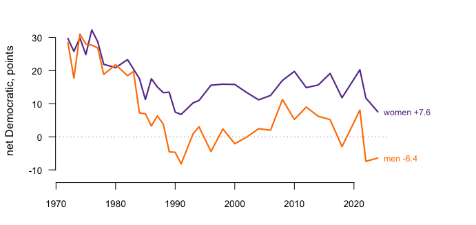

**Both lines fall.** Men went from +28.4 to -6.4, a move of 34.9 points. Women went from +29.7 to +7.6, a move of 22.2.

Women did not become more Democratic. They became less Democratic, by more than twenty points. The gap opened because **men moved 1.57 times as far in the same direction.**

| Decade | Years | Men | Women | Gap |
| --- | --- | --- | --- | --- |
| 1970s | 7 | +25.5 | +27.6 | 2.1 |
| 1980s | 9 | +9.2 | +17.0 | 7.8 |
| 1990s | 6 | -1.8 | +11.2 | 13.0 |
| 2000s | 5 | +2.7 | +14.0 | 11.3 |
| 2010s | 5 | +4.5 | +16.3 | 11.7 |
| 2020s | 3 | -1.9 | +13.2 | 15.1 |

The decade averages say the same thing more slowly. Every column falls. The last one rises because the first two fall at different speeds.

This is worth holding onto beyond one number, because a gap is a difference, and a difference discards the level. Two series moving together by twenty points and two series moving apart by twenty points can produce the identical gap, and no amount of care in reporting the gap will recover which happened. Several of this book’s most-quoted numbers run the same way. The turnout brief reports a gap whose halves both moved, and the thermometers brief finds a famous polarization number that is one half doing all the work. Ask for the pair. It is one extra number and it changes the sentence.

One more subtraction, larger than the first. Split women by marital status and a bigger gap appears inside the smaller one.

| Group | Net Democratic |
| --- | --- |
| Unmarried women | +19.1 |
| Married women | -5.4 |
| Unmarried men | -2.5 |
| Married men | -9.1 |

In 2024, unmarried women were +19.1 and married women -5.4. That is 24.5 points between two groups of women, against 14.0 points between women and men. **The split inside the category is wider than the split between categories.** Anybody reporting one number for women is averaging across a difference larger than the one they are reporting.

## What this brief cannot tell you

**`sex` here is two boxes.** The GSS records sex, not gender identity, and for most of this series it was coded by the interviewer. The file gained a different item, `sexnow1`, which was asked in 2021-2022 of 7,455 respondents. That is too few years to carry a fifty-two-year comparison, so it is counted here and not used. Nothing in this brief speaks to people for whom the two items differ.

**Party identification is not a vote.** It is what somebody says they are, not what they did, and the two come apart. Whether the leaners belong with the party they lean toward is a decision this brief made, and the party identification brief finds the same choice moving a headline number by a factor of five.

**These are cross-sections, not the same people.** Each year’s survey draws a fresh sample; nobody is followed from one round to the next, as a panel study would do. A series that falls can fall because individuals changed their minds, or because the people who held the old view died and were replaced. Nothing here separates those, and they are different countries.

**The composition of each group changed underneath the line.** “Women” in 1972 and “women” in 2024 differ in education, marital status, race and age. Some of the movement in Figure 2 is those compositions changing rather than anybody’s politics.

**And a gap is not an explanation.** This brief shows which side moved. It does not say why, and the literature on why is large and unsettled.[^1]

## What you should have learned

- Both sexes moved away from the Democratic Party across this series: men by 34.9 points and women by 22.2, in the same direction, on the same question, weighted the same way.
- The gap grew from 2.1 points in the 1970s to 15.1 in the 2020s, and every point of that growth is a difference in speed, not a difference in direction.
- The most-quoted version of the number cannot show any of that, because one line cannot show two movements — a difference has no memory of its halves.
- The marriage gap among women, 24.5 points in 2024, is wider than the 14.0-point gap between women and men in the same year.

## Extensions

None of these is answered above, and every one can be answered from the tables the Sources section hands over.

- `partyid_by_sex.csv` has `men` and `women` separately, and the `gap` between them. Plot all three. Which of the two lines is doing the moving?
- `partyid_by_sex_marital.csv` splits the same people again by marital status. Compare the gap between `married_women` and `unmarried_women` against the gap between women and men. Which subtraction is bigger?
- `by_decade.csv` collapses the series into decades. Compare its `gap` column against the year-by-year file. What does the smoothing hide?
- `partyid_by_sex.csv` carries `n_men` and `n_women` for every year. Find the thinnest years. Would you report a gap that size off a sample that size?

Two stretch ideas point past the spreadsheet. The ANES asks its own seven-point party question — download the cumulative file the ANES chapter describes and check whether its gender gap matches the GSS’s in size and in timing. And the gap in *identification* is not the gap in *votes*: find a published exit-poll gender gap for a recent presidential election and decide which of Figure 2’s two lines it says more about.

## Sources

**Data**

- **General Social Survey**, cumulative file, release 3a (2024), NORC at the University of Chicago. 75,699 respondents, 1972–2024, weight `wtssps`. https://gss.norc.org/us/en/gss/get-the-data.html
- **GSS documentation**, including the codebook that defines `partyid`, `sex` and `wtssps`. https://gss.norc.org/us/en/gss/get-documentation.html
- **The tables here.** Nine columns of that file, cut down to the small tables this brief reads; the source is not kept in this folder, the tables are. Every number above is computed from them at the moment this document was rendered, and checked against the assertions below.

**Academic literature**

- Kaufmann, Karen M. and John R. Petrocik (1999). “The Changing Politics of American Men: Understanding the Sources of the Gender Gap.” *American Journal of Political Science* 43(3): 864–887. https://www.jstor.org/stable/2991798
- Box-Steffensmeier, Janet M., Suzanna De Boef and Tse-Min Lin (2004). “The Dynamics of the Partisan Gender Gap.” *American Political Science Review* 98(3): 515–528. https://doi.org/10.1017/S0003055404001315

| Check | Passed |
| --- | --- |
| the Stata file is where this script expects it | yes |
| the whole cumulative file arrived, not one wave | yes |
| every row carries the weight this chapter uses | yes |
| the newer item covers a small minority of the file | yes |
| the series is continuous enough to draw | yes |
| no year rests on fewer than a hundred of either | yes |
| both series move in the same direction across the series | yes |
| the gap is wider at the end than at the start | yes |
| the 1970s gap is small and the 2020s gap is not | yes |
| the marriage split among women is not smaller than the sex gap that year | yes |

**The data itself**

Every figure above is drawn from these tables. They are plain CSV, they open in a spreadsheet, and they are yours to take further.

`by_decade.csv`, `partyid_by_sex.csv`, `partyid_by_sex_marital.csv`

Two more files here are not data about the subject at all – they are how this chapter checked its own work: `facts.csv`, the individual numbers the text above quotes, and `checks.csv`, the arithmetic verified before anything was drawn.

Rebuild this data yourself, with an AI assistant

```
I want to rebuild a public dataset from its original source, without any
starting files. Please do the following and show your work.

THE SOURCE. NORC at the University of Chicago, General Social Survey
cumulative data file, release 3a, covering every survey from 1972 to
2024. One zip, about 47 MB, published at
https://gss.norc.org/content/dam/gss/get-the-data/documents/stata/GSS_stata.zip
No account or key is needed. Inside is a single Stata file, about
570 MB unpacked, with 75,699 rows and 6,943 columns. Each row is one
person NORC interviewed, in whatever year they were interviewed. You
will need software that can read a Stata file.

HOW TO DOWNLOAD IT. The server sometimes turns away plain scripted
downloads. If a script is refused, download the zip in an ordinary
browser and start from the file — it is the same object either way.

WHAT TO BUILD.
1. For every survey year, the net Democratic identification of men and
   of women, weighted with the WTSSPS weight: the weighted share who
   identify as or lean Democratic (PARTYID codes 0, 1, 2) minus the
   share who identify as or lean Republican (codes 4, 5, 6). Code 7,
   "other party", belongs to neither side; drop it. The gender gap is
   the women's number minus the men's.
2. A count of the respondents dropped as "other party", and a count
   of the respondents ever asked the newer SEXNOW1 gender question.

CHECK YOUR WORK. The copy this book used was downloaded in August 2026.
If your rebuild matches it, you should find:
- 75,699 respondents in the file, 1972 through 2024
- 73,696 of them with both a sex and a usable party identification
- 1,375 dropped for naming another party
- 7,455 ever asked the newer gender question, all in 2021 and 2022
NORC issues a new release every year or two; if the file at that
address has grown, the numbers changed because the data were extended
or revised, not because you made an error.
```

[^1]: Two starting points, one arguing that the gap opened because men moved and one modelling its dynamics: Karen M. Kaufmann and John R. Petrocik, “The Changing Politics of American Men: Understanding the Sources of the Gender Gap,” *American Journal of Political Science* 43, no. 3 (1999): 864–887, https://www.jstor.org/stable/2991798; Janet M. Box-Steffensmeier, Suzanna De Boef and Tse-Min Lin, “The Dynamics of the Partisan Gender Gap,” *American Political Science Review* 98, no. 3 (2004): 515–528, https://doi.org/10.1017/S0003055404001315.